# Laboratorio: Ejercicios variables aleatorias

# Números aleatorios uniformes

## Método del cuadrado medio

Se desarrollará el ejemplo del cuadrado medio propuesto por Von Neumann y Stanislaw Ulam. La siguiente función cm ejecuta el proceso tomando un valor inicial.

```r
cm <- function(x) {
# A partir de la semilla x, se genera una sucesión de valores,
# tomando los valores de enmedio de la serie
  u <- x/10^nchar(as.character(x)) # primer uniforme
  z <- x # copia de trabajo
  repeat{
    # verifica que el número tenga suficientes dígitos
    z <- z^2
    n <- nchar(z)
    if (n < 6) break
    # partiendo de un tamaño de 7 dígitos, escogemos los dígitos centrales y vamos recorriendo
    z <- as.numeric(as.character(substr(z, n-5, n-2)))
    u <- append(u, z/10000)
    if ((u[length(u)] == 0 ) | length(unique(u)) < length(u)) break #si el último número es 0 o ya se repiten termina
  }
  return(u)
}
```

Podemos ver que los problemas de **cm** son que genera secuencias o muy cortas o convierte rápidamente a 0

```r
# converge rápido a 0:
cm(1009)
```

```
[1] 0.1009 0.0180
```

```r
# ciclos cortos:
cm(898775)
```

```
[1] 0.898775 0.500600 0.060000 0.360000 0.960000 0.160000 0.560000 0.360000
```

Considerando otro número para un ciclo más largo (por ejemplo $5675431$), ¿qué tan aleatorios se ven los números y cómo lo podemos verificar? ¿Qué pruebas podemos hacer para verificar aleatoriedad? Algunos ejemplos se muestran a continuación

```r
z0 <- 5675431
u <- cm(z0)
u
```

```
 [1] 0.5675431 0.0357000 0.1274000 0.6230000 0.8129000 0.0806000 0.6496000 0.1980000 0.9204000 0.7136000 0.9224000
[12] 0.0821000 0.6740000 0.4276000 0.2841000 0.0712000 0.5069000 0.6947000 0.2608000 0.8016000 0.2562000 0.5638000
[23] 0.7870000 0.9369000 0.7781000 0.5439000 0.5827000 0.9539000 0.9925000 0.5056000 0.5631000 0.7081000 0.1405000
[34] 0.9740000 0.8676000 0.2729000 0.4474000 0.0166000
```

```r
J <- seq(556734, 1000000, by = 100)
i <- NULL
for (j in J) i[match(j,J)] <- length(cm(j))
head(i,20)
```

```
 [1] 64 25 22 13 23 73 12 14 34  8 59 54  5 54 50 33  8 24 11 15
```

```r
max(i)
```

```
[1] 98
```

## GLC con parámetros inadecuados

Este ejemplo genera una animación de un glc con parámetros inadecuados, y genera números aleatorios que no pasarían pruebas de uniformidad.

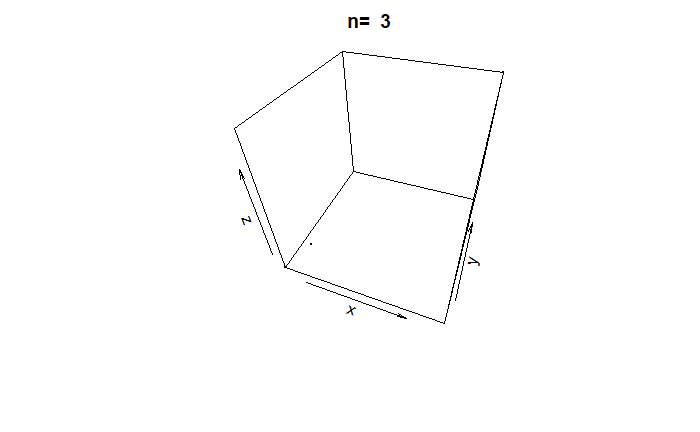

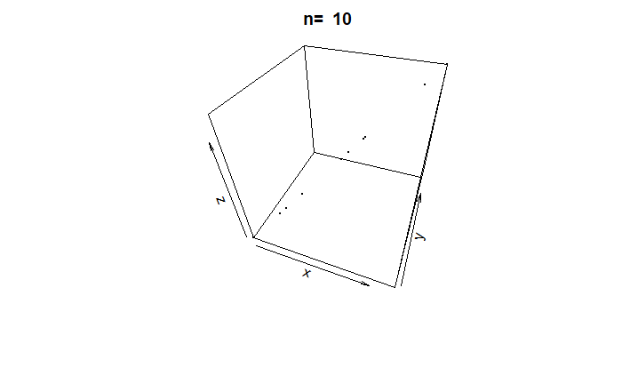

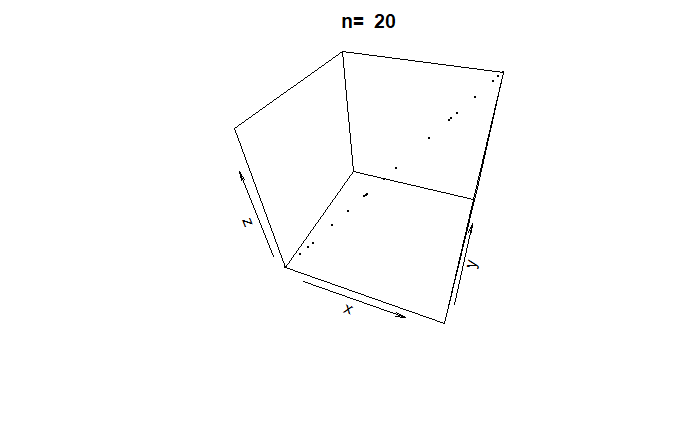

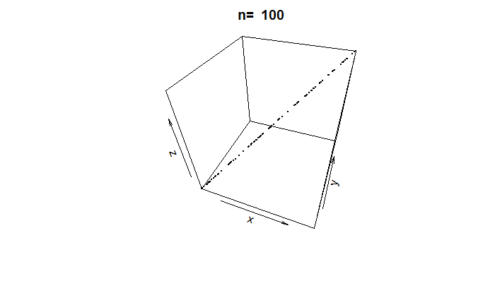

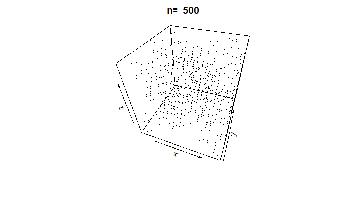

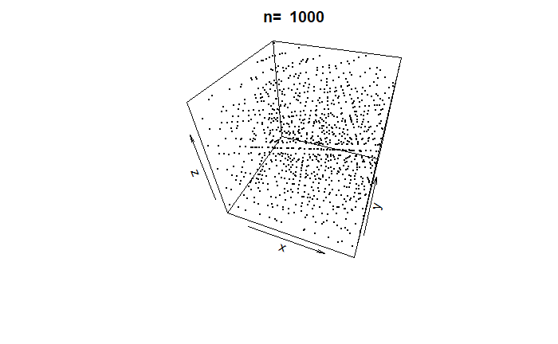

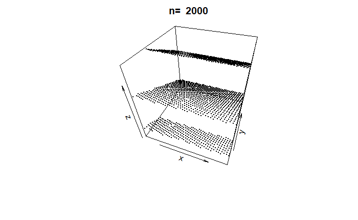

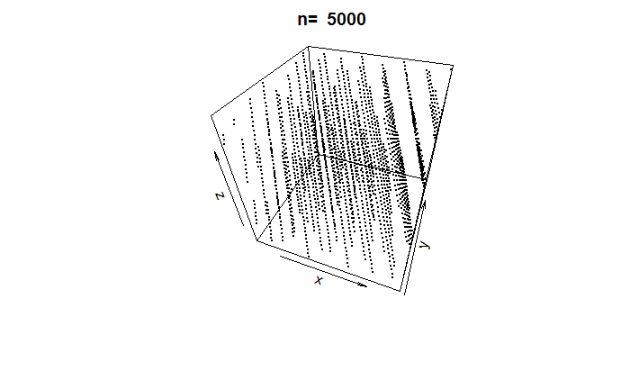

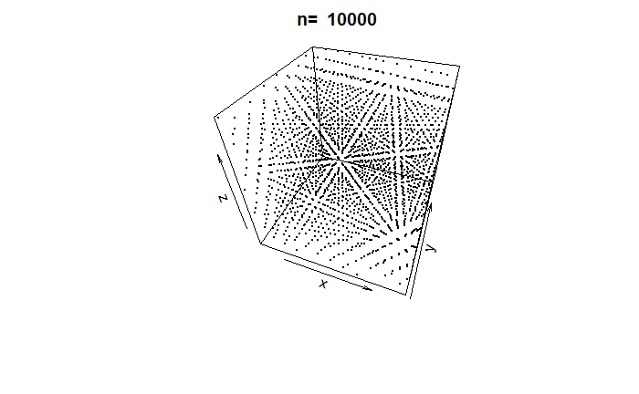

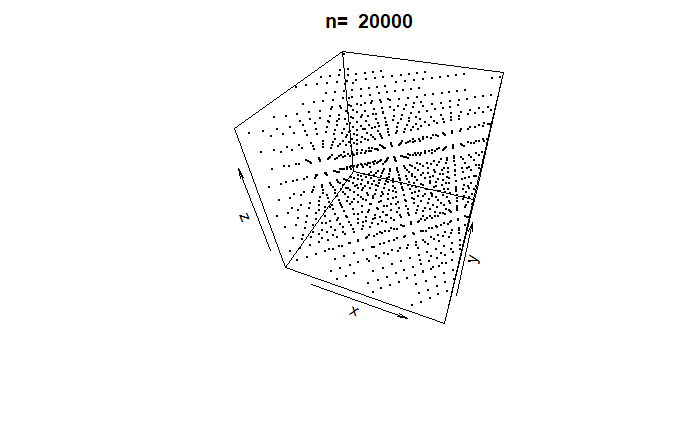

```r
library(plot3D)
library(animation)
lcg.poor <- function(n){
# http://www.aaronschlegel.com/linear-congruential-generator-r/
rng <- vector(length=n)
m <- 2048
a <- 1229
c <- 1
d <- as.numeric(Sys.time())*1000 #genera una semilla del reloj de la compu

for (i in 1:n){
    d <- (a*d+c) %% m
    rng[i] <- d/m
 }
 return(rng)
}
n <- c(3,10,20,100,500,1000,2000,5000,10000,20000)
#saveGIF({
  for (i in 1:length(n)){
    x <- lcg.poor(n[i])
    y <- lcg.poor(n[i])
    z <- lcg.poor(n[i])

  scatter3D(x,y,z, colvar = NULL, pch=20, cex=0.5,
                   theta = 20,
                   main =paste("n= ",n[i]))
  }
```

```r
#}, movie.name="lcg_poor.gif")
```

## GLC’s

Veremos cómo afectan las constantes a los generadores lineales congruenciales. Prueben con distintos números y verifiquen el teorema de Hull y Dubell, así como el teorema para GLC’s multiplicativos.

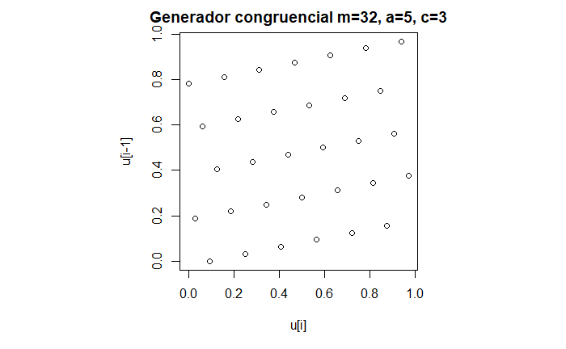

```r
lgc  <- function(m=16,a=5,c=3,z0=7,graf=T){
  #esta función genera un lgc hasta que alcanza su periodo
            z <- z0
            i <- 1
            repeat {
                i <- i+1
                z[i] <- (a*z[i-1] + c) %% m
                if(i>m) break
            }
          if (graf){
              par(pty="s")
              plot(z[2:(m+1)]/m, z[1:m]/m,
                  xlab = "u[i]", ylab = "u[i-1]", main =
                  paste0("Generador congruencial m=",m,", a=",a,", c=",c))
          }
          return(z/m)
        }
z <- lgc(m=32,a=5,c=3)
```

### Uso de semilla aleatoria

Fijando una semilla podemos generar de nuevo las mismas secuencias de números aleatorios.

```r
set.seed(10)
runif(5)
```

```
[1] 0.50747820 0.30676851 0.42690767 0.69310208 0.08513597
```

```r
runif(5)
```

```
[1] 0.2254366 0.2745305 0.2723051 0.6158293 0.4296715
```

```r
set.seed(10)
runif(5)
```

```
[1] 0.50747820 0.30676851 0.42690767 0.69310208 0.08513597
```

```r
runif(5)
```

```
[1] 0.2254366 0.2745305 0.2723051 0.6158293 0.4296715
```

Podemos cambiar el generador de núeros aleatorios por default.

```r
RNGkind() #nos dice cuál es el activo
```

```
[1] "Mersenne-Twister" "Inversion"
```

```r
RNGkind("Super-Duper")
RNGkind()
```

```
[1] "Super-Duper" "Inversion"
```

```r
runif(10)
```

```
 [1] 0.9369764 0.7930306 0.9279180 0.7451378 0.1379861 0.7655856 0.5102004 0.2363813 0.7377337 0.7662446
```

```r
RNGkind("Mersenne-Twister")
runif(10)
```

```
 [1] 0.89234990 0.26727022 0.77760553 0.81290681 0.94691778 0.75388182 0.07369741 0.29062250 0.43896930 0.24246660
```

El paquete *randtoolbox* facilita utilizar algunos generadores, por ejemplo:

```r
library(rngWELL)
library(randtoolbox)
congruRand(10, mod=2^31-1, mult = 16807, incr = 0)
```

```
 [1] 0.92027533 0.06755026 0.31719086 0.02674624 0.52397727 0.48597122 0.71826431 0.86825074 0.69026822 0.33792272
```

```r
library(rgl) #visualización en 3D
```

[output not shown]

Ejercicio: Programar un generador de Fibonacci: $Z_i \equiv (Z_{i-r}+Z_{i-s}) \mod m$

# Números de otras distribuciones.

## Teorema de la transformación integral de probabilidad

Ejercicio 1: Generar una muestra de 1000 números aleatorios exponenciales con parámetro $\lambda$ usando números aleatorios uniformes. Hacer su histograma y comparar con la densidad teórica.

Ejercicio 2: Generar una muestra de 1000 números aleatorios con distribución Cauchy. Hacer su histograma y comparar con la densidad teórica.

Ejercicio 3: Generar una muestra aleatoria de 1000 números aleatorios con distribución geométrica con parámetro $p$

Ejercicio 4: Generar una muestra de 1000 variables Poisson con parámetro $\lambda$ y verificar que proviene efectivamente de una Poisson.